# Лабораторная работа №10

Операционные системы - Бекауов А.Т

Российский университет дружбы народов, Москва, Россия

# Введение

## Цель работы

Цель данной лабораторной работы -познакомиться с операционной системой Linux. Получить практические навыки работы с редактором vi, установленным по умолчанию практически во всех дистрибутивах.

# Выполнение лабораторной работы

## Задание 1: Подготовка к выполнению

Сначала с помощью команды mkdir с ключом p создаю каталог с именем м ~/work/os/lab06, затем перехожу в этот каталог, создаю в нём файл hello.sh и открываю его в текстовом редакторе vi.

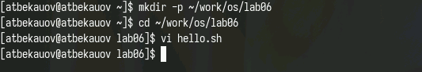

## Задание 1: Ввод текста

Далее перехожу в режим вставки нажав клавишу i и набираю там предложенный в методичке текст. По завершение перехожу в командный режим нажав кнопку ESC

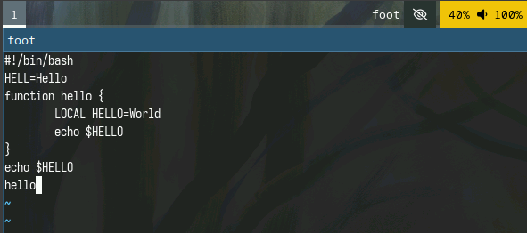

## Задание 1: Сохранение и выход

Затем перехожу в режим последней строки нажав “:”, и набираю внизу wq, чтобы записть (сохранить) файл и выйти из vi.

[figure not shown]

## Задание 1: редактирование прав доступа

С помощью команды chmod делаем файл исполняемым.

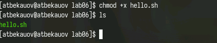

## Задание 2: Редактирование в режиме вставки

Вызываю vi на редактирование файла hello.sh, устанавливаю курсор на конец слова HELL и ,перейдя в режим вставки (i), дописываю его до HELLO. По завершение возвращаюсь в командный режим (ESC)

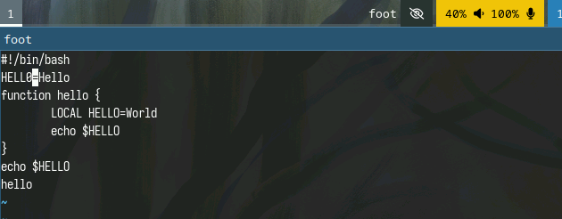

## Задание 2: Удаление слова в командном режиме

Устанавливаю курсор на четвертую строку в начало слова LOCAL и прожимаю комбинацию клавиш d+w, чтобы удалить это слово

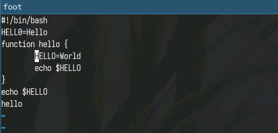

## Задание 2: Редактирование в режиме вставки

В режиме вставки дописываю на месте LOCAL слово local, возвращаюсь в командный режим и перевожу курсор на последнюю строчку.

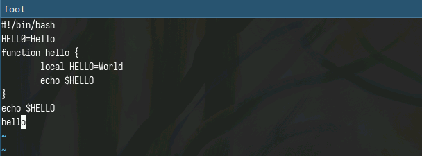

## Задание 2: Редактирование в режиме вставки

Перехожу в режим вставки (i) и перейдя на строчку после последней, набираю текст “echo $HELLO”, затем нажимаю ESC, чтобы перейти обратно в командный режим.

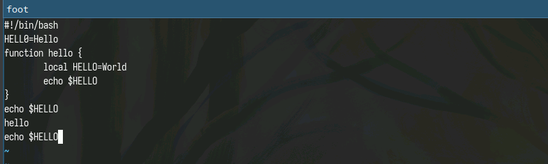

## Задание 2: Удаление строки

Курсор находится на последней строчке. Нажимаю комбинацию “d+d”, и удаляю строчку на которой располагался курсор.

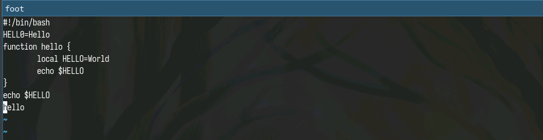

## Задание 2 : Отмена действия

Затем нажимаю клавишу “u”, чтобы отменить последнее действие и вернуть обратно последнюю строку. Затем перехожу в режим последней строки (:) и набираю wq, чтобы сохранить файл и покинуть vi.

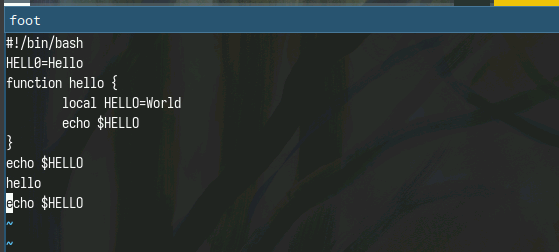

# Заключение

## Выводы

В ходе данной лаботраторной работы я познакомился с операционной системой Linux. Получил практические навыки работы с редактором vi, установленным по умолчанию практически во всех дистрибутивах.